# TP Tests statistiques

Erivan INAN, M2 ISDS, 2025

```
                                                  TP TESTS
```

**————————————————————– IMPORTATION DES LIBRAIRIES NÉCESSAIRES ————————————————————-**

```r
# bibliothèques nécessaires
library(ggplot2) # Pour l'affichage des graphes
library(DescTools)  # Pour test de la médiane
library(goftest) # Pour Anderson-Darling
library(nortest) # Pour Cramer-Von Mises
library(coin) # Pour Wilcoxon-Mann-Whitney
library(stats) # Pour tests de tendance et KS
library(dplyr) # Pour l'analyse des résultats
library(reshape2) # Pour le redimensionnement
library(RColorBrewer) # Pour la palette de couleurs graphiques
library(tidyr)
```

**———————————————————————————- PARAMÉTRISATION ——————————————————————————**

Je commence par définir les paramètres de ma simulation pour tester la performance de plusieurs tests statistiques sur différentes tailles d’échantillons. Je commence par fixer une graine aléatoire avec set.seed(123) afin d’assurer la reproductibilité de mes résultats. Ensuite, je choisis plusieurs tailles d’échantillon (n_valeurs), allant de 10 à 1000, et je décide de répéter chaque test 2000 fois (M) pour obtenir des résultats fiables. Je crée ensuite une sorte de dictionnaire, dans une liste contenant les noms des tests statistiques, en distinguant ceux appliqués lorsque H0 est proche ou loin de la vérité.

Enfin, j’initialise une liste vide resultats_list, qui me servira à stocker les résultats des simulations une fois les tests appliqués.

```r
# Définition des paramètres
set.seed(123)
n_valeurs <- c(10, 50, 100, 500, 1000)  # Différentes tailles d'échantillon
M <- 2000  # Nombre de répétitions

# Définition des noms des tests (ajout des variantes proche/loin)
noms_tests <- c(
  "mediane_proche", "mediane_loin",
  "quantile_proche", "quantile_loin",
  "wilcoxon_proche", "wilcoxon_loin",
  "mann_whitney_proche",
  "kolmogorov_smirnov_proche", "kolmogorov_smirnov_loin",
  "cramer_von_mises_proche", "cramer_von_mises_loin",
  "anderson_darling_proche", "anderson_darling_loin"
)

# Initialisation d'une liste pour stocker les résultats
resultats_list <- list()
```

**——————————————————————————————– BOUCLE —————————————————————————————**

Dans ce code, je mets en place la boucle de simulation pour tester la performance des différents tests statistiques sur des échantillons de tailles variées.

Pour chaque taille d’échantillon n dans n_valeurs, je répète M=2000 fois la génération de données et l’application des tests.

Je commence par initialiser un vecteur rejets pour stocker le nombre de rejets de H0 pour chaque test.

Ensuite, je génère trois jeux de données :

- Si H0 vrai : Un échantillon uniforme U(0,3).
- Si H0 légèrement faux : Un échantillon uniforme légèrement décalé U(0.1,3.1).
- Si H0 complètement faux : Un échantillon issu d’une loi exponentielle Exp(1), qui est très différente de U(0,3).

J’applique différents tests pour comparer les échantillons générés à une loi uniforme :

**————————————————————————— APPLICATION DES TESTS STATISTIQUES**

Tests d’adéquation : Kolmogorov-Smirnov, Cramer-Von Mises et Anderson-Darling.

Pour chacun d’eux, je réalise un test pour H0 proche (comparaison avec U(0.1,3.1)) et un test pour H0 loin (comparaison avec Exp(1)).

Si la p-value obtenue est inférieure à 0.05, alors H0 est rejeté et j’incrémente le compteur de rejets correspondant.

**————————————————————————— NORMALISATION DES RÉSULTATS**

Après les 2000 itérations, je normalise les taux de rejet en divisant par M. J’ajoute ces résultats à la liste resultats_list, en associant chaque vecteur de rejets à la taille d’échantillon correspondante. Une fois la boucle terminée, je convertis cette liste en data.frame avec do.call(rbind, resultats_list), puis je m’assure que toutes les colonnes sont bien numériques.

Enfin, j’affiche les résultats avec print(resultats) pour vérifier que tout fonctionne comme prévu. Ce code me permet ainsi d’évaluer comment la taille de l’échantillon influence la puissance des tests statistiques à détecter un écart entre la distribution simulée et U(0,3).

```r
# Boucle de simulation et tests
for (n in n_valeurs) {

  # Initialisation des compteurs de rejets
  rejets <- numeric(length(noms_tests))
  names(rejets) <- noms_tests

  for (i in 1:M) {

    # 1. Simulation de la loi uniforme U(0,3) (H0 vrai)
    ech_uniforme <- runif(n, min=0, max=3)

    # 2. Simulation de lois alternatives pour H0 loin de la vérité
    ech_alternatif_loin <- rexp(n, rate = 1)  # Loi exponentielle (clairement différente de U(0,3))

    # 3. Simulation d'une loi légèrement différente pour H0 proche
    ech_alternatif_proche <- runif(n, min=0.1, max=3.1)  # Légèrement décalée

    # 4. Test bilatéral sur la médiane
    test_mediane_proche <- wilcox.test(ech_uniforme, mu=1.4, alternative="two.sided")
    if (test_mediane_proche$p.value < 0.05) rejets["mediane_proche"] <- rejets["mediane_proche"] + 1

    test_mediane_loin <- wilcox.test(ech_uniforme, mu=2.5, alternative="two.sided")
    if (test_mediane_loin$p.value < 0.05) rejets["mediane_loin"] <- rejets["mediane_loin"] + 1

    # 5. Tests de Kolmogorov-Smirnov
    test_ks_proche <- ks.test(ech_alternatif_proche, "punif", 0, 3)
    if (test_ks_proche$p.value < 0.05) rejets["kolmogorov_smirnov_proche"] <- rejets["kolmogorov_smirnov_proche"] + 1

    test_ks_loin <- ks.test(ech_alternatif_loin, "punif", 0, 3)
    if (test_ks_loin$p.value < 0.05) rejets["kolmogorov_smirnov_loin"] <- rejets["kolmogorov_smirnov_loin"] + 1

    # 6. Tests de Cramer-Von Mises
    test_cvm_proche <- goftest::cvm.test(ech_alternatif_proche, null="punif", min=0, max=3)
    if (test_cvm_proche$p.value < 0.05) rejets["cramer_von_mises_proche"] <- rejets["cramer_von_mises_proche"] + 1

    test_cvm_loin <- goftest::cvm.test(ech_alternatif_loin, null="punif", min=0, max=3)
    if (test_cvm_loin$p.value < 0.05) rejets["cramer_von_mises_loin"] <- rejets["cramer_von_mises_loin"] + 1

    # 7. Tests d'Anderson-Darling
    test_ad_proche <- goftest::ad.test(ech_alternatif_proche, null="punif", min=0, max=3)
    if (test_ad_proche$p.value < 0.05) rejets["anderson_darling_proche"] <- rejets["anderson_darling_proche"] + 1

    test_ad_loin <- goftest::ad.test(ech_alternatif_loin, null="punif", min=0, max=3)
    if (test_ad_loin$p.value < 0.05) rejets["anderson_darling_loin"] <- rejets["anderson_darling_loin"] + 1
  }

  # Normalisation des taux de rejet
  rejets <- rejets / M

  # Stockage des résultats dans une liste
  resultats_list[[as.character(n)]] <- c(n = n, rejets)
}

# Conversion de la liste en data frame final
resultats <- do.call(rbind, resultats_list)
resultats <- as.data.frame(resultats)

# Forcer toutes les colonnes à être numériques
resultats[] <- lapply(resultats, as.numeric)

# Vérification des résultats
print(resultats)
```

```
##         n mediane_proche mediane_loin quantile_proche quantile_loin
## 10     10         0.0580       0.8685               0             0
## 50     50         0.1055       1.0000               0             0
## 100   100         0.1920       1.0000               0             0
## 500   500         0.7000       1.0000               0             0
## 1000 1000         0.9430       1.0000               0             0
##      wilcoxon_proche wilcoxon_loin mann_whitney_proche
## 10                 0             0                   0
## 50                 0             0                   0
## 100                0             0                   0
## 500                0             0                   0
## 1000               0             0                   0
##      kolmogorov_smirnov_proche kolmogorov_smirnov_loin cramer_von_mises_proche
## 10                      0.0470                  0.5345                  0.0540
## 50                      0.0825                  0.9935                  0.0990
## 100                     0.1230                  1.0000                  0.1700
## 500                     0.4465                  1.0000                  0.6310
## 1000                    0.8135                  1.0000                  0.9275
##      cramer_von_mises_loin anderson_darling_proche anderson_darling_loin
## 10                   0.570                   0.311                0.8165
## 50                   0.998                   0.840                1.0000
## 100                  1.000                   0.970                1.0000
## 500                  1.000                   1.000                1.0000
## 1000                 1.000                   1.000                1.0000
```

**————————————————————————— TRANSFORMATION DES DONNÉES ——————————————————————**

J’utilise pivot_longer() pour convertir mon data.frame resultats en format long, ce qui facilite la création du graphique.

Avant l’application de la fonction, les colonnes représentent chaque test individuellement. Après, chaque ligne correspond à un test appliqué à une certaine taille d’échantillon n, avec une colonne supplémentaire indiquant le taux de rejet observé.

J’ajoute ensuite une nouvelle colonne Test_base en supprimant les suffixes _proche et _loin pour regrouper les tests sous une même catégorie. Ensuite, j’ajoute une colonne Condition qui indique si H0 est proche ou loin de la vérité.

Finalement, j’affiche les premières lignes de resultats_long avec print(head(resultats_long)) pour vérifier que la transformation a bien fonctionné et que les nouvelles colonnes (Test_base et Condition) sont correctement définies.

```r
# Transformer les données en format long
resultats_long <- resultats %>%
  pivot_longer(cols = -n, names_to = "Test", values_to = "Taux_rejet")

# Ajouter une colonne pour distinguer H0 proche et loin
resultats_long <- resultats_long %>%
  mutate(
    Test_base = gsub("_proche|_loin", "", Test),  # Extraire le nom du test
    Condition = ifelse(grepl("_proche", Test), "H0 proche", "H0 loin")
  )

# Vérification des données
print(head(resultats_long))
```

```
## # A tibble: 6 × 5
##       n Test            Taux_rejet Test_base Condition
##   <dbl> <chr>                <dbl> <chr>     <chr>
## 1    10 mediane_proche       0.058 mediane   H0 proche
## 2    10 mediane_loin         0.868 mediane   H0 loin
## 3    10 quantile_proche      0     quantile  H0 proche
## 4    10 quantile_loin        0     quantile  H0 loin
## 5    10 wilcoxon_proche      0     wilcoxon  H0 proche
## 6    10 wilcoxon_loin        0     wilcoxon  H0 loin
```

**————————————————————– VISUALISATION GRAPHIQUE DES RÉSULTATS ———————————————————–**

J’utilise ggplot() pour tracer le taux de rejet en fonction de la taille d’échantillon :

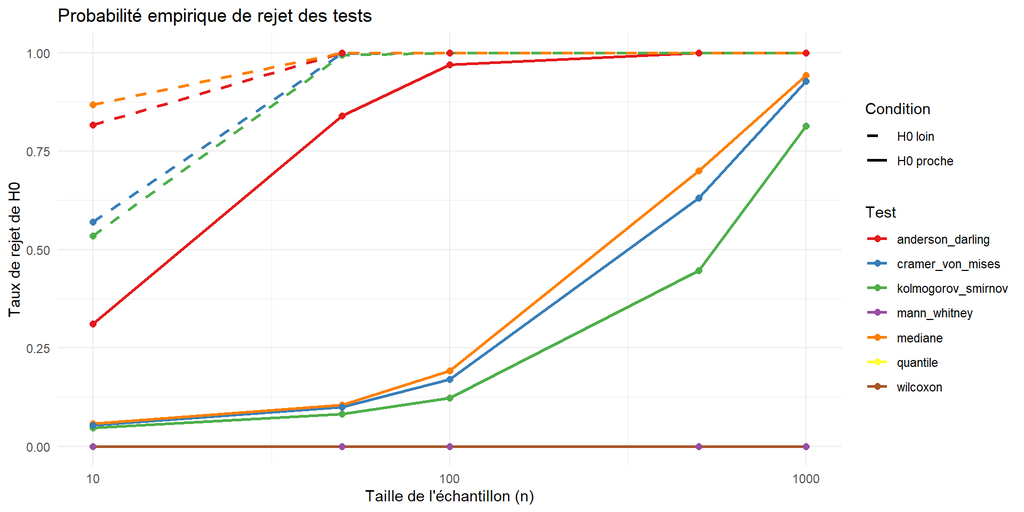

```r
# Tracé du graphique
ggplot(resultats_long, aes(x = n, y = Taux_rejet, color = Test_base, linetype = Condition)) +
  geom_line(linewidth = 1) +  # lignes des courbes
  geom_point(size = 2) +      # points visibles
  scale_x_log10() +           # échelle logarithmique
  scale_color_brewer(palette = "Set1") +  # couleurs uniques par test
  scale_linetype_manual(values = c("H0 proche" = "solid", "H0 loin" = "dashed")) +  # Styles de lignes
  labs(title = "Probabilité empirique de rejet des tests",
       x = "Taille de l'échantillon (n)",
       y = "Taux de rejet de H0",
       color = "Test",
       linetype = "Condition") +
  theme_minimal() +
  theme(legend.position = "right")
```

**———————————————————————————- ANALYSE GÉNÉRALE ———————————————————————**

Le graphique représente le taux de rejet empirique de H0 en fonction de la taille d’échantillon n pour plusieurs tests statistiques. Chaque test est différencié par sa couleur, et l’effet de H0 proche ou loin de la vérité est indiqué par le type de ligne (pleine = H0 proche, pointillée = H0 loin).

- Quand H0 est loin de la vérité (lignes pointillées) :

- Quand H0 est proche de la vérité (lignes pleines) :

Les taux de rejet sont plus bas, ce qui est attendu, car il est plus difficile de distinguer une distribution légèrement différente de U(0,3). Les tests comme Kolmogorov-Smirnov, Cramer-Von Mises et Anderson-Darling montrent une augmentation progressive du taux de rejet avec la taille d’échantillon.

**———————————————————————————- ANALYSE PAR TEST ————————————————————————–**

————————————————– **Anderson-Darling (rouge)** :

————————————————– **Cramer-Von Mises (bleu)** :

- H0 loin : Atteint un taux de rejet de 1 rapidement (n ≥ 50), indiquant une haute sensibilité.
- H0 proche : Augmente régulièrement, ce qui montre qu’il est adapté pour des petits écarts.

————————————————– **Kolmogorov-Smirnov (vert)** :

- H0 loin : Devient efficace dès n = 100.
- H0 proche : Plus conservateur, il détecte les différences plus tardivement que les autres tests d’adéquation.

————————————————– Médiane (orange) :

————————————————– **Quantile (jaune)** :

————————————————– **Wilcoxon (marron) et Mann-Whitney (violet)** :

**—————————————————————————————– CONCLUSION —————————————————————————–**

Les tests d’adéquation comme Anderson-Darling, Cramer-Von Mises et Kolmogorov-Smirnov sont très efficaces pour détecter des écarts lorsque la distribution réelle est loin de U(0,3), bien que Kolmogorov-Smirnov soit plus conservateur que les autres.